# Expressions and order of operations

- Show All Code
- Hide All Code

Course v1.1 lesson 5

Julia

Programming

Expressions

Published

October 5, 2026

# Lesson 005: Expressions and order of operations

**Learning goal:** Expressions and order of operations.

**Prerequisites:** None.

**Time:** 15-30 minutes. **Status:** Completed

## 1. Concept and notation

Arithmetic expressions represent a precise sequence of operations. Python uses ** for powers and parentheses to group terms. Julia uses ^ for powers. A number alone has no physical unit.

Arithmetic

Here is an example of how to use arithmetic.

```
f(x) = 0.659*x^2 + 34.4*x - 65.4
xs = LinRange(0, 10, 50)
ys = [f(x) for x in xs]
```

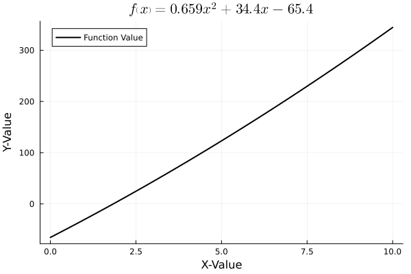

````julia
using Plots
gr()

disty = "text/markdown"

display(disty, "## Arithmetic")
display(disty, "Here is an example of how to use arithmetic.")

f(x) = 0.659*x^2 + 34.4*x - 65.4
xs = LinRange(0, 10, 50)
ys = [f(x) for x in xs]

display(disty, "
```julia
f(x) = 0.659*x^2 + 34.4*x - 65.4
xs = LinRange(0, 10, 50)
ys = [f(x) for x in xs]
```
")

plot(xs, ys, lw=2, lc=:black, label="Function Value")
title!("\$ f\\left(x\\right) = 0.659x^2 + 34.4x - 65.4\$")
xlabel!("X-Value")
ylabel!("Y-Value")
````

## 2. Worked example (different from the exercise)

```python
For a square of side 3, area is 3**2 = 9. In (2+3)*4, grouping gives 20; 2+3*4 gives 14.
```

Explain the example in words before proceeding.

```julia
L = 3
A = L^2

a = 2
b = 3
c = 4

result1 = (a + b)*c
result2 = a + b*c

println("Result with grouping is $result1")
println("Result without grouping is $result2")
```

```
Result with grouping is 20
Result without grouping is 14
```

## 3. Required exercise

1. Predict 6+4*3 and (6+4)*3 by hand.
2. Evaluate both in Python and explain the difference.
3. Evaluate (12-5)/2 and 2**5.

```julia
display(disty, "### Excercise Answers")

display(disty, "1. I predict that \$6+4 \\times 3 = 18\$ and that \$\\left(6+4\\right) \\times 3 = 30\$")

result1 = 6+4*3
result2 = (6+4)*3

display(disty, "2. The first method produces $result1 and the second method produces $result2")

result3 = (12-5)/2
result4 = 2^5

display(disty, "3. The first result is $result3 and the second is $result4")
```

Excercise Answers

1. I predict that $6+4 \times 3 = 18$ and that $\left(6+4\right) \times 3 = 30$

2. The first method produces 18 and the second method produces 30

3. The first result is 3.5 and the second is 32

## 4. Checks and interpretation

Hand calculation and Python agree; parentheses change the intended grouping; results include explanatory sentences.

Write why each check is appropriate. Use only taught constructs; plain calculations and written checks are sufficient.

```julia
# No code checks here today
```

## 5. Reflection

What does the result mean? Which assumption limits the model? Which earlier idea did you reuse?

```julia
# nothing for now
```

## 6. Optional stretch

Write two different expressions with the same numerical result and explain their operations.

```
When x=1, we have f1 = 7, and f2 = 7
This works because the two functions are not parallel and intersect at x = 1
 You can see from the plot below:
```

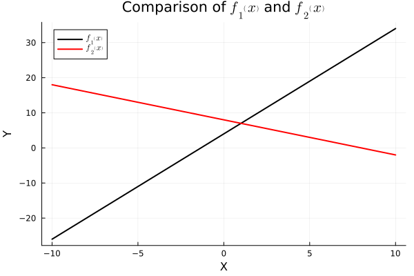

```julia
f1(x) = 3x + 4
f2(x) = -x + 8

println("When x=1, we have f1 = $(f1(1)), and f2 = $(f2(1))")
println("This works because the two functions are not parallel and intersect at x = 1\n You can see from the plot below:\n")

xs = LinRange(-10, 10, 100)
y1s = [f1(x) for x in xs]
y2s = [f2(x) for x in xs]

plot(xs, y1s, lw=2, lc=:black, label="\$f_1\\left(x\\right)\$")
plot!(xs, y2s, lw=2, lc=:red, label="\$f_2\\left(x\\right)\$")
plot!(grid=true)
title!("Comparison of \$f_1\\left(x\\right)\$ and \$f_2\\left(x\\right)\$")
xlabel!("X")
ylabel!("Y")
```

## 7. Reading and continuity

Required reading: explanation and worked example above. Optional accessible background: [OpenStax Algebra and Trigonometry 2e](https://openstax.org/details/books/algebra-and-trigonometry-2e) and [Python introductory tutorial](https://docs.python.org/3/tutorial/introduction.html). Read only the relevant arithmetic/function material, not advanced sections.